# Capstone Quiz I

Complete all **Exercises**, and submit answers to **Questions** on the Coursera platform.

This initial quiz will concern exploratory data analysis (EDA) of the Ames Housing dataset. EDA is essential when working with any source of data and helps inform modeling.

First, let us load the data:

```r
library(dplyr)
load("ames_train.Rdata")
```

1. Which of the following are the three variables with the highest number of missing observations?
   1. `Misc.Feature`, `Alley`, `Pool.QC`

```r
sum(is.na(ames_train$Misc.Feature))
```

```
## [1] 971
```

```r
sum(is.na(ames_train$Fence))
```

```
## [1] 798
```

```r
sum(is.na(ames_train$Pool.QC))
```

```
## [1] 997
```

```r
sum(is.na(ames_train$Alley))
```

```
## [1] 933
```

```r
sum(is.na(ames_train$Fireplace.Qu))
```

```
## [1] 491
```

```r
sum(is.na(ames_train$Lot.Frontage))
```

```
## [1] 167
```

2. How many categorical variables are coded in R as having type `int`? Change them to factors when conducting your analysis.
   1. 3

```r
names(ames_train %>% select_if(is.integer))
```

```
##  [1] "PID"             "area"            "price"
##  [4] "MS.SubClass"     "Lot.Frontage"    "Lot.Area"
##  [7] "Overall.Qual"    "Overall.Cond"    "Year.Built"
## [10] "Year.Remod.Add"  "Mas.Vnr.Area"    "BsmtFin.SF.1"
## [13] "BsmtFin.SF.2"    "Bsmt.Unf.SF"     "Total.Bsmt.SF"
## [16] "X1st.Flr.SF"     "X2nd.Flr.SF"     "Low.Qual.Fin.SF"
## [19] "Bsmt.Full.Bath"  "Bsmt.Half.Bath"  "Full.Bath"
## [22] "Half.Bath"       "Bedroom.AbvGr"   "Kitchen.AbvGr"
## [25] "TotRms.AbvGrd"   "Fireplaces"      "Garage.Yr.Blt"
## [28] "Garage.Cars"     "Garage.Area"     "Wood.Deck.SF"
## [31] "Open.Porch.SF"   "Enclosed.Porch"  "X3Ssn.Porch"
## [34] "Screen.Porch"    "Pool.Area"       "Misc.Val"
## [37] "Mo.Sold"         "Yr.Sold"
```

```r
# MS.Subclas, Overall.Qual, Overall.Cond
ames_train$MS.SubClass <- as.factor(ames_train$MS.SubClass)
ames_train$Overall.Qual <- as.factor(ames_train$Overall.Qual)
ames_train$Overall.Cond <- as.factor(ames_train$Overall.Cond)
```

3. In terms of price, which neighborhood has the highest standard deviation?
   1. `StoneBr`

```r
ames_train %>% group_by(Neighborhood) %>% summarise(sd = sd(price)) %>% arrange(desc(sd))
```

```
## # A tibble: 27 x 2
##    Neighborhood     sd
##    <fct>         <dbl>
##  1 StoneBr      123459
##  2 NridgHt      105089
##  3 Timber        84030
##  4 Veenker       72545
##  5 Crawfor       71268
##  6 GrnHill       70711
##  7 Somerst       65199
##  8 Edwards       54852
##  9 CollgCr       52786
## 10 SawyerW       48354
## # ... with 17 more rows
```

4. Using scatter plots or other graphical displays, which of the following variables appears to be the best single predictor of `price`?
   1. `Overall.Qual`

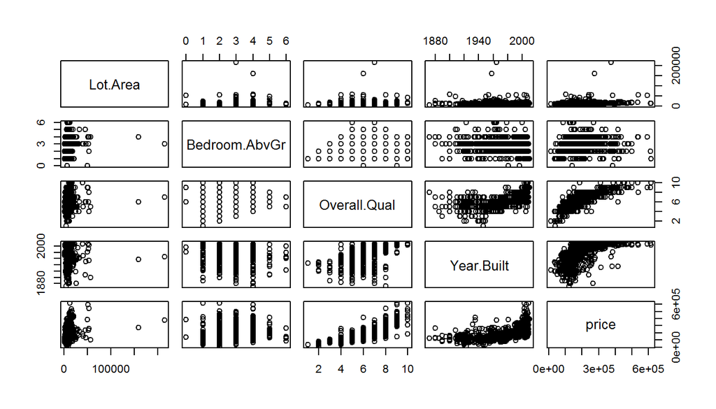

```r
# type your code for Question 4 here, and Knit
q4 <- ames_train %>% select("Lot.Area", "Bedroom.AbvGr", "Overall.Qual", "Year.Built", "price")
pairs(q4)
```

5. Suppose you are examining the relationship between `price` and `area`. Which of the following variable transformations makes the relationship appear to be the most linear?
   1. Log-transform both `price` and `area`

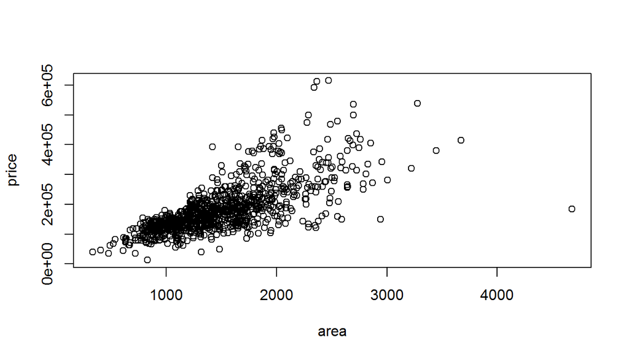

```r
attach(ames_train)
plot(area, price)
```

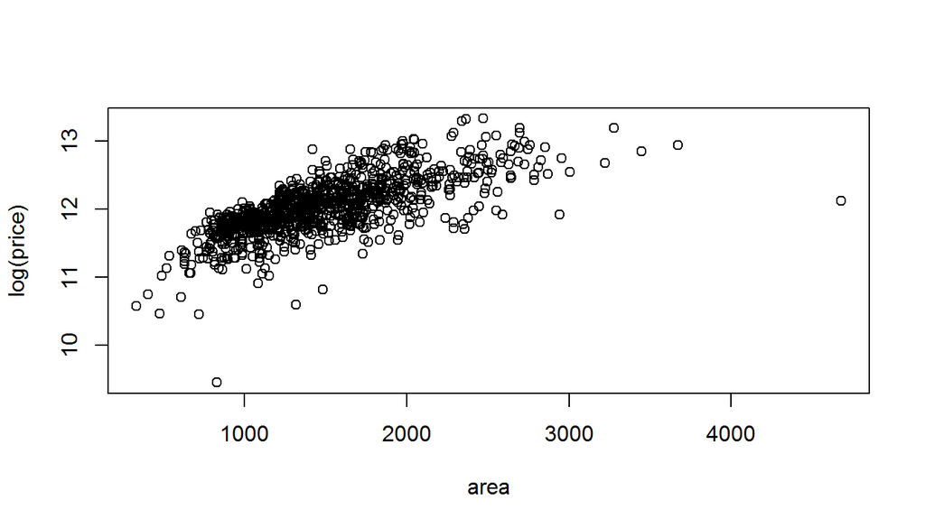

```r
plot(area, log(price))
```

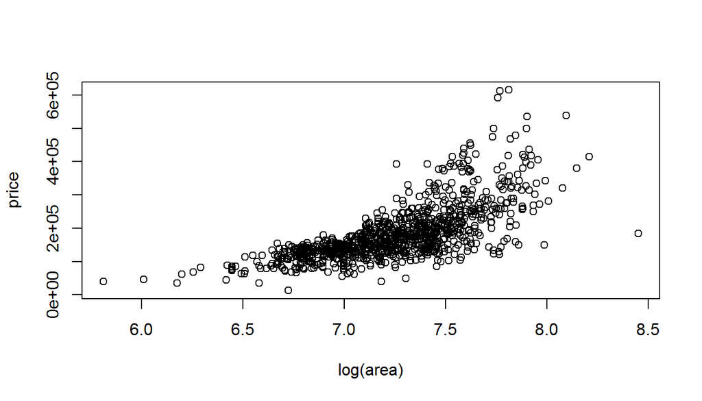

```r
plot(log(area), price)
```

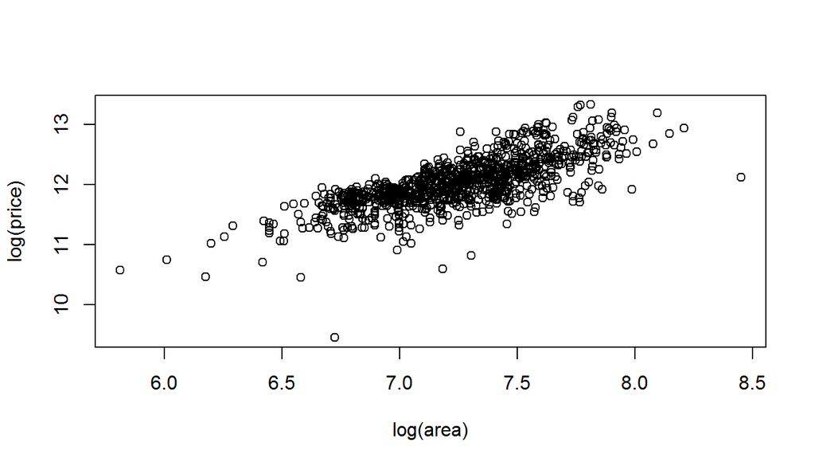

```r
plot(log(area), log(price))
```

6. Suppose that your prior for the proportion of houses that have at least one garage is Beta(9, 1). What is your posterior? Assume a beta-binomial model for this proportion.
   1. Beta(963, 47)

```r
sum(!is.na(ames_train$Garage.Type))
```

```
## [1] 954
```

7. Which of the following statements is true about the dataset?
   1. 21 houses do not have a basement.

```r
(sum(ames_train$Year.Built > 1999)) / nrow(ames_train)
```

```
## [1] 0.272
```

```r
(median(ames_train$price) > mean(ames_train$price))
```

```
## [1] FALSE
```

```r
(sum(is.na(ames_train$Bsmt.Qual)))
```

```
## [1] 21
```

8. Test, at the $\alpha = 0.05$ level, whether homes with a garage have larger square footage than those without a garage.
   1. With a p-value near 0.000, we reject the null hypothesis of no difference.

```r
areawo <- ames_train %>% filter(is.na(Garage.Type)) %>% select(area)
areaw <-  ames_train %>% filter(!is.na(Garage.Type)) %>% select(area)
t.test(areaw$area, areawo$area)
```

```
##
##  Welch Two Sample t-test
##
## data:  areaw$area and areawo$area
## t = 5.1395, df = 50.692, p-value = 4.452e-06
## alternative hypothesis: true difference in means is not equal to 0
## 95 percent confidence interval:
##  211.7760 483.3425
## sample estimates:
## mean of x mean of y
##  1492.603  1145.043
```

9. For homes with square footage greater than 2000, assume that the number of bedrooms above ground follows a Poisson distribution with rate $\lambda$. Your prior on $\lambda$ follows a Gamma distribution with mean 3 and standard deviation 1. What is your posterior mean and standard deviation for the average number of bedrooms in houses with square footage greater than 2000 square feet?
   1. Mean: 3.62, SD: 0.16

```r
q9 <- ames_train %>% filter(area > 2000) %>% select(Bedroom.AbvGr)
k0 <- 9
theta0 <- 1/3
sigma_xi <- sum(q9$Bedroom.AbvGr)
n <- length(q9$Bedroom.AbvGr)

k <- k0 + sigma_xi
theta <- theta0 / (n * theta0+1)

postMean <- k * theta
postSd <- theta * sqrt(k)
```

10. When regressing $\log$(`price`) on $\log$(`area`), there are some outliers. Which of the following do the three most outlying points have in common?
    1. They were built before 1930.

```r
# type your code for Question 10 here, and Knit
fit <- lm(log(price) ~ log(area), data = ames_train)
sq_error <- fit$residuals^2
sorted <- sort.int(sq_error, decreasing = TRUE, index.return = TRUE)
ames_train[sorted$ix[1:3],] %>% select(Sale.Condition, Bedroom.AbvGr, Overall.Qual, Year.Built)
```

```
## # A tibble: 3 x 4
##   Sale.Condition Bedroom.AbvGr Overall.Qual Year.Built
##   <fct>                  <int> <fct>             <int>
## 1 Abnorml                    2 2                  1923
## 2 Normal                     3 4                  1920
## 3 Abnorml                    3 4                  1910
```

11. Which of the following are reasons to log-transform `price` if used as a dependent variable in a linear regression?
    1. both a and b

```r
# type your code for Question 11 here, and Knit
```

12. How many neighborhoods consist of only single-family homes? (e.g. `Bldg.Type` = `1Fam`)
    1. 3

```r
# Find neighborhoods with single family homes
nwsfh <- ames_train %>% group_by(Neighborhood) %>% filter(Bldg.Type == '1Fam') %>% select(Neighborhood)

# Find homes by neighborhood and type
hbt  <- ames_train %>% group_by(Neighborhood, Bldg.Type) %>% summarise(Counts = n())  %>% filter(Neighborhood %in% nwsfh$Neighborhood)

# Count number of occurrences of each neighborhood having single family homes
xsfh <- hbt %>% group_by(Neighborhood) %>% summarise(Count = n())

# Neighborhoods with only single family homes occur just once in the above data frame
xsfh %>% filter(Count == 1)
```

```
## # A tibble: 3 x 2
##   Neighborhood Count
##   <fct>        <int>
## 1 ClearCr          1
## 2 NoRidge          1
## 3 Timber           1
```

13. Using color, different plotting symbols, conditioning plots, etc., does there appear to be an association between $\log$(`area`) and the number of bedrooms above ground (`Bedroom.AbvGr`)?
    1. Yes

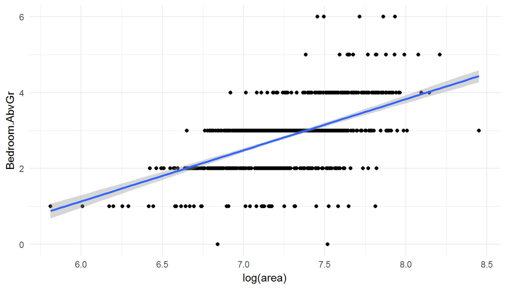

```r
library(ggplot2)
ggplot(ames_train, aes(x = log(area), y = Bedroom.AbvGr)) +
  geom_point() +
  geom_smooth(method=lm) +
  theme_minimal()
```

14. Of the people who have unfinished basements, what is the average square footage of the unfinished basement?
    1. 595.25

```r
aveSqFt <- ames_train %>% filter(!is.na(Bsmt.Unf.SF) & Bsmt.Unf.SF!=0) %>% summarize(AveSqFt = mean(Bsmt.Unf.SF))
```